# Credit scoring

Wiktoria Szczypka

30 maja 2019

## Wstęp

Celem tego projektu będzie wykonanie kilku modeli, które pozwolą prognozować indywidualne ryzyko kredytowe, tj. czy udzielić komuś kredyt mieszkaniowy czy nie. Po wykonaniu modeli postaram wybrać się ten, który będzie najbardziej wiarygodny i z największą skutecznością pozwoli oceniać na podstawie zmiennych objaśniających czy można danej osobie udzielić kredytu. Dane na podstawie, których wykonam modele to historyczne informacje o danej osobie oraz to czy udzielono jej kredytu mieszkaniowego. Podzielę te dane na uczące i testowe. Modele wykonam na zbiorze uczącym, a następnie ocenię model na zbiorze testowym.

W swoim badaniu użyję 4 metod:

- regresji logistycznej,
- klasyfikatora naiwnego Bayesa,

oraz 2 metod tworzenia drzew decyzyjnych:

- boosting,
- lasy losowe.

Poniżej przedstawiam strukturę danych, na których będę wykonywać projekt.

```
## 'data.frame':    614 obs. of  13 variables:
##  $ Loan_ID          : Factor w/ 614 levels "LP001002","LP001003",..: 1 2 3 4 5 6 7 8 9 10 ...
##  $ Gender           : Factor w/ 3 levels "","Female","Male": 3 3 3 3 3 3 3 3 3 3 ...
##  $ Married          : Factor w/ 3 levels "","No","Yes": 2 3 3 3 2 3 3 3 3 3 ...
##  $ Dependents       : Factor w/ 5 levels "","0","1","2",..: 2 3 2 2 2 4 2 5 4 3 ...
##  $ Education        : Factor w/ 2 levels "Graduate","Not Graduate": 1 1 1 2 1 1 2 1 1 1 ...
##  $ Self_Employed    : Factor w/ 3 levels "","No","Yes": 2 2 3 2 2 3 2 2 2 2 ...
##  $ ApplicantIncome  : int  5849 4583 3000 2583 6000 5417 2333 3036 4006 12841 ...
##  $ CoapplicantIncome: num  0 1508 0 2358 0 ...
##  $ LoanAmount       : int  NA 128 66 120 141 267 95 158 168 349 ...
##  $ Loan_Amount_Term : int  360 360 360 360 360 360 360 360 360 360 ...
##  $ Credit_History   : int  1 1 1 1 1 1 1 0 1 1 ...
##  $ Property_Area    : Factor w/ 3 levels "Rural","Semiurban",..: 3 1 3 3 3 3 3 2 3 2 ...
##  $ Loan_Status      : Factor w/ 2 levels "N","Y": 2 1 2 2 2 2 2 1 2 1 ...
```

Jak widać moje dane posiadają 614 obserwacji oraz 13 zmiennych:

- Loan_ID - jest to indywidualny numer każdej obserwacji, zmienna ta nie jest potrzebna do dalszego badania - usunę ją.
- Gender - zmienna płeć jest to zmienna czynnikowa - przyjmuje trzy wartości - mężczyzna, kobieta oraz brak. Pusta wartość oznacza, że brakuje informacji na temat płci, zamienię tą wartość na NA i zmienna płeć będzie miała dwa czynniki.
- Married - zmienna to oznacza czy ktoś jest w związku małżeńskim. Również jest to zmienna czynnikowa i przyjmuje trzy wartości - tak, nie oraz pustą wartość, którą podobnie jak wcześniej zamienię na NA.
- Dependents - liczba osób zależnych od osoby ubiegającej się o kredyt. Jest to zmienna czynnikowa i przyjmuje 5 poziomów - 0, 1, 2, 3+ oraz pusty, który jak wcześniej zamienię na wartości NA.
- Education - zmienna czynnikowa z dwoma poziomami - tak i nie, która oznacza, czy osoba ubiegająca się o kredyt ma wykształcenie wyższe.
- Self_Employed - oznacza czy dana osoba jest samozatrudniona. Jest to zmienna czynnikowa z trzema poziomami - tak, nie oraz pusty, który zamienię na wartości NA.
- ApplicantIncome - zmienna numeryczna oznaczająca przychód wnioskującego o kredyt.
- CoapplicantIncome - również zmienna numeryczna oznaczająca przychód współwnioskującego o kredyt.
- LoanAmount - zmienna numeryczna oznaczająca kwotę kredytu w tysiącach.
- Loan_Amount_Term - zmienna numeryczna oznaczająca długość trwania pożyczki w miesiącach.
- Credit_History - zmienna numeryczna oznaczająca czy przeszłość kredytowa danej osoby spełnia wytyczne. Zamienię ją na zmienną czynnikową z dwoma poziomami - tak oraz nie.
- Property_Area - zmienna czynnikowa, która oznacza, gdzie jest posiadłość na którą wnioskodawca chce uzyskać kredyt. Przyjmuje ona trzy wartości - wiejski, półmiejski oraz miejski.
- Loan_Status - zmienna objaśniana, również czynnikowa z dwoma poziomami - tak oraz nie. Oznacza czy dana osoba uzyskała kredyt.

Poniżej kod, który umożliwia wykonanie mi zmian w danych o których pisałam wyżej. Zmienię również poziomy zmiennej Loan_Status na 0 oraz 1.

```r
data <- data[,-1]
data$Credit_History <- as.factor(data$Credit_History)
levels(data$Gender)[levels(data$Gender)==""] <- NA
levels(data$Married)[levels(data$Married)==""] <- NA
levels(data$Dependents)[levels(data$Dependents)==""] <- NA
levels(data$Self_Employed)[levels(data$Self_Employed)==""] <- NA

#LoanStatus - Y = 1, N = 0
levels(data$Loan_Status) = c(0,1)
```

### Statystyki opisowe

Przedstawię teraz podstawowe statystyki opisowe zmiennych.

```
##     Gender    Married    Dependents        Education   Self_Employed
##  Female:112   No  :213   0   :345   Graduate    :480   No  :500
##  Male  :489   Yes :398   1   :102   Not Graduate:134   Yes : 82
##  NA's  : 13   NA's:  3   2   :101                      NA's: 32
##                          3+  : 51
##                          NA's: 15
##
##
##  ApplicantIncome CoapplicantIncome   LoanAmount    Loan_Amount_Term
##  Min.   :  150   Min.   :    0     Min.   :  9.0   Min.   : 12
##  1st Qu.: 2878   1st Qu.:    0     1st Qu.:100.0   1st Qu.:360
##  Median : 3812   Median : 1188     Median :128.0   Median :360
##  Mean   : 5403   Mean   : 1621     Mean   :146.4   Mean   :342
##  3rd Qu.: 5795   3rd Qu.: 2297     3rd Qu.:168.0   3rd Qu.:360
##  Max.   :81000   Max.   :41667     Max.   :700.0   Max.   :480
##                                    NA's   :22      NA's   :14
##  Credit_History   Property_Area Loan_Status
##  0   : 89       Rural    :179   0:192
##  1   :475       Semiurban:233   1:422
##  NA's: 50       Urban    :202
##
##
##
##
```

Można zauważyć, że aż w 7 zmiennych objaśniających występują wartości NA. Zajmę się nimi w następnym kroku.

Poza tym ze statystyk można wyciągnąć iż w zbiorze danych jest więcej:

- mężczyzn niż kobiet,
- osób w związku małżeńskim niż bez,
- osób, które nie posiadają osób zależnych od siebie,
- osób, które posiadają wykształcenie wyższe,
- osób, które nie są samozatrudnione,
- osób z historią kredytową,
- posiadłości na terenach półmiejskich - nie są to jednak aż tak duże różnice.

Widać również duża rozbieżność w zmiennej ApplicantIncome oraz CoapplicantIncome - występują zarobki bardzo małe, a również olbrzymie. Kwota kredytu waha się od 9 do 700, a jej średnia to 146,4. Czas trwania kredytu waha się od 12 do 480 miesięcy.

W przypadku zmiennej objaśnianej widać, że więcej razy udzielono kredytu niż odmówiono.

W celu lepszej wizualizacji danych przedstawię histogramy dla zmiennych czynnikowych oraz wykresy pudełkowe dla zmiennych numerycznych.

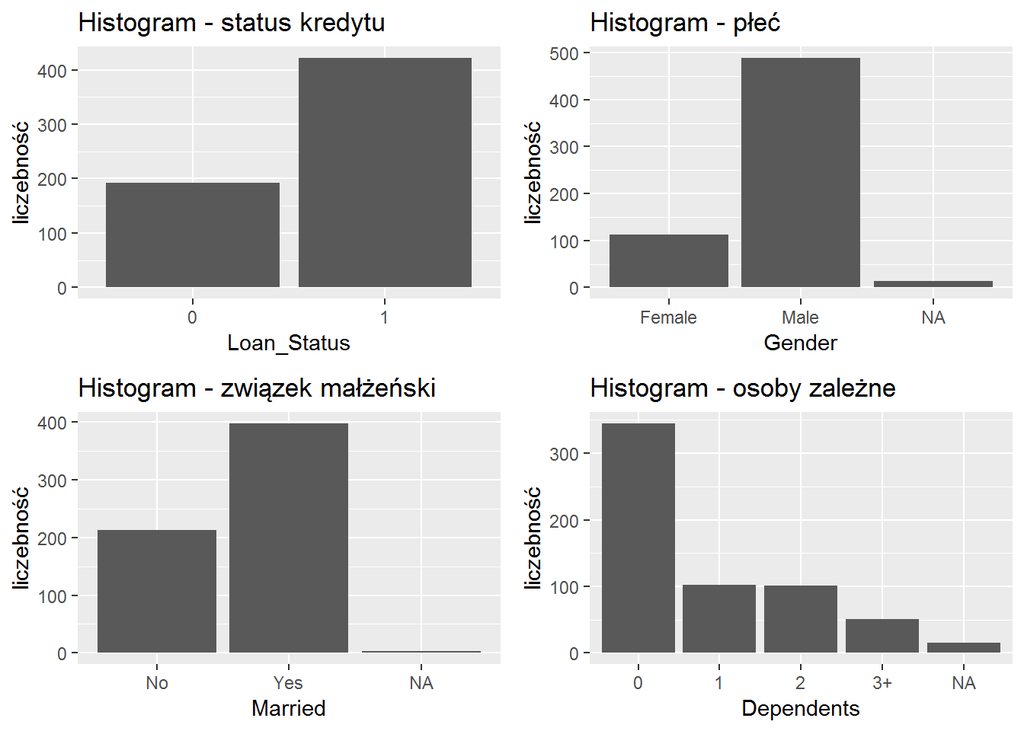

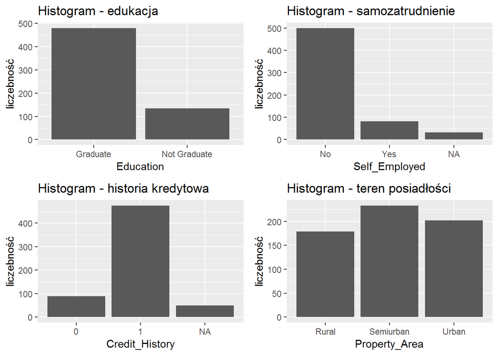

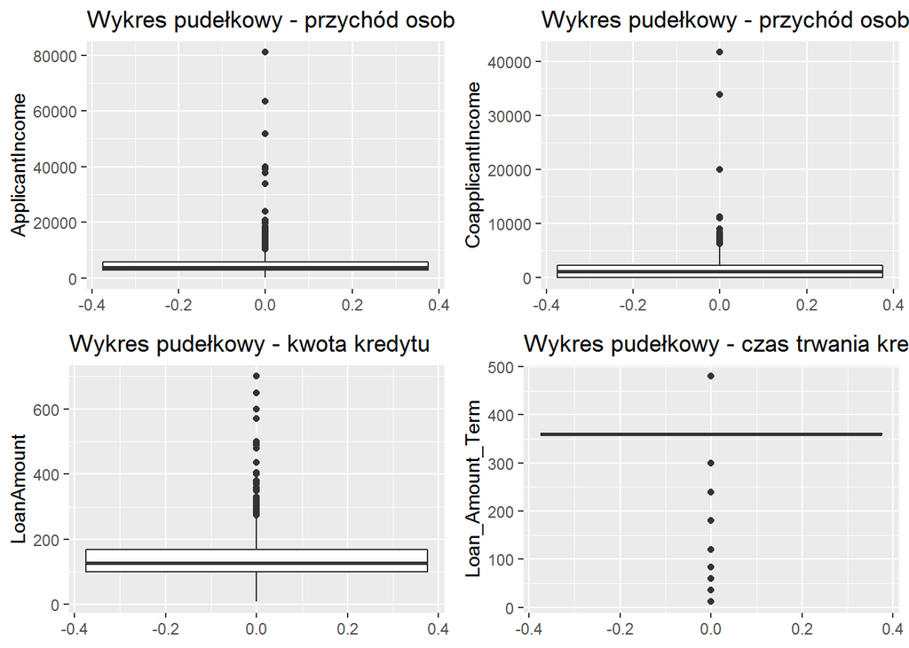

Powyższe wykresy dobrze wizualizują wcześniej zamieszczone statystyki opisowe. W przypadku wykresów pudełkowych można zauważyć, że występuje dużo wartości odstających - będę się nimi zajmować w dalszej części projektu. Patrząc się na wykres zmiennej czas trwania pożyczki można się zastanowić czy nie warto zamienić jej na zmienną czynnikową. Poniżej przedstawiam jej histogram.

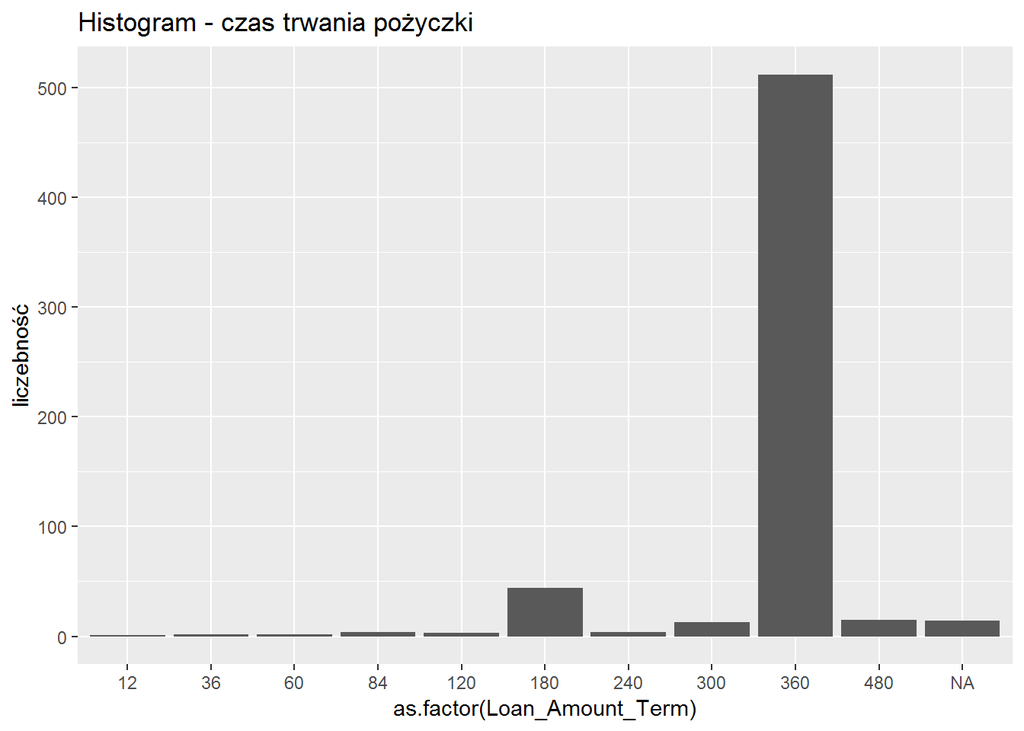

Można zauważyć, że głównie pożyczkę udziela się na 360 miesięcy, a potem na 180. Pozostałe wartości występują rzadko. Zostawiam tą zmienną jako numeryczną, ze względu na to, że zmienna ta może przyjmować również inne wartości, a nie tylko te w zbiorze danych.

### Zależności

Przedstawię teraz zależności jakie występują między zmiennymi objaśniającymi, a objaśnianą.

Najpierw przedstawię tabele dla zmiennych czynnikowych.

- zmienna płeć

```
##
##            0   1
##   Female  37  75
##   Male   150 339
```

- zmienna małżeństwo

```
##
##         0   1
##   No   79 134
##   Yes 113 285
```

- zmienna osoby zależne

```
##
##        0   1
##   0  107 238
##   1   36  66
##   2   25  76
##   3+  18  33
```

- zmienna edukacja

```
##
##                  0   1
##   Graduate     140 340
##   Not Graduate  52  82
```

- zmienna samozatrudnienie

```
##
##         0   1
##   No  157 343
##   Yes  26  56
```

- zmienna historia kredytowa

```
##
##       0   1
##   0  82   7
##   1  97 378
```

- zmienna miejsce posiadłości

```
##
##               0   1
##   Rural      69 110
##   Semiurban  54 179
##   Urban      69 133
```

W przypadku zmiennej edukacja można zauważyć, że osoby z wykształceniem w większym stopniu uzyskiwały kredyt. Przy zmiennej historia kredytowa widać dużą dysproporcję - osoby, które nie posiadają historii kredytowej zgodnej z oczekiwaniami banku rzadko uzyskują kredyt. Zależność można również odkryć przy zmiennej miejsce posiadłości - częściej uzyskuje się kredyt na posiadłość w terenie półmiejskim. W przypadku pozostałych zmiennych nie zauważyłam żadnych zależności.

Poniżej wykresy pudełkowe dla zmiennych numerycznych w zależności od tego czy uzyskano kredyt czy też nie.

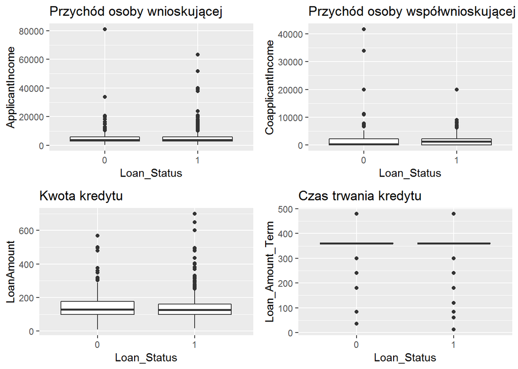

Można zauważyć, że w zmiennej przychód osoby współwnioskującej mediana jest większa przy uzyskaniu kredytu. Jednak co zaskakujące skrajnie duży przychód zarówno w przychodzie osoby wnioskującej jak i współwnioskującej nie zapewniły uzyskania kredytu. Myślę, że są to wartości odstające, gdyż nie jest to logiczne. Może być to też spowodowane złą przeszłością kredytową lub niebezpieczną inwestycją. W pozostałych zmiennych nie widać zależności.

## Przygotowanie danych

W tej części zajmę się przygotowaniem danych do docelowego badania. Zacznę od obserwacji z wartościami NA, następnie zajmę się problemem wartości odstających, a na samym końcu podzielę zbiór danych na uczący i testowy.

### Obserwacje z wartościami NA

Zacznę od przedstawienia ile występuje wartości NA w każdej zmiennej.

```
##            Gender           Married        Dependents         Education
##                13                 3                15                 0
##     Self_Employed   ApplicantIncome CoapplicantIncome        LoanAmount
##                32                 0                 0                22
##  Loan_Amount_Term    Credit_History     Property_Area       Loan_Status
##                14                50                 0                 0
```

Można zauważyć, że wartości NA jest sporo. Zbiór danych ma około 600 obserwacji, więc usunięcie wartości NA bardzo by go pomniejszyło. Ze względu na to wybieram metodę dzięki której będę w stanie wypełnić te wartości.

W moim badaniu do uzupełnienia wartości NA posłużę się funkcją `mice` z pakietu o tej samej nazwie. Automatycznie dobiera ona najlepszą metodę uzupełniania dla danej zmiennej. Każda niekompletna zmienna jest przypisywana za pomocą osobnego modelu. Ze zmiennych na podstawie, których funkcja ta będzie przewidywać wartości NA usuwam zmienną objaśnianą, aby nie zakłamało to późniejszych wyników. Następnie za pomocą `complete` uzupełniam początkowe dane wartościami uzyskanymi dzięki funkcji `mice`.

Przedstawię poniżej jakie metody uzupełniania wartości dobrała ta funkcja dla zmiennych.

```
##            Gender           Married        Dependents         Education
##          "logreg"          "logreg"         "polyreg"                ""
##     Self_Employed   ApplicantIncome CoapplicantIncome        LoanAmount
##          "logreg"                ""                ""             "pmm"
##  Loan_Amount_Term    Credit_History     Property_Area       Loan_Status
##             "pmm"          "logreg"                ""                ""
```

Dla zmiennych binarnych - Gender, Married, Self_Employed oraz Credit_History została dobrana regresja logistyczna. Dla zmiennej czynnikowej Dependents aproksymacji wielomianowej. Natomiast dla zmiennych numerycznych LoanAmount oraz Loan_Amount_Term użyto metody Predictive Mean Matching (przewidywania średnich).

Poniżej przedstawię nowe statystyki opisowe.

```
##     Gender    Married   Dependents        Education   Self_Employed
##  Female:114   No :215   0 :352     Graduate    :480   No :528
##  Male  :500   Yes:399   1 :104     Not Graduate:134   Yes: 86
##                         2 :107
##                         3+: 51
##
##
##  ApplicantIncome CoapplicantIncome   LoanAmount    Loan_Amount_Term
##  Min.   :  150   Min.   :    0     Min.   :  9.0   Min.   : 12.0
##  1st Qu.: 2878   1st Qu.:    0     1st Qu.:100.0   1st Qu.:360.0
##  Median : 3812   Median : 1188     Median :128.0   Median :360.0
##  Mean   : 5403   Mean   : 1621     Mean   :146.1   Mean   :342.4
##  3rd Qu.: 5795   3rd Qu.: 2297     3rd Qu.:166.8   3rd Qu.:360.0
##  Max.   :81000   Max.   :41667     Max.   :700.0   Max.   :480.0
##  Credit_History   Property_Area Loan_Status
##  0: 99          Rural    :179   0:192
##  1:515          Semiurban:233   1:422
##                 Urban    :202
##
##
##
```

Widać już, że nie występują wartości NA, a statystyki nieznacząco się zmieniły.

### Wartości odstające

Jak już wspomniałam wcześniej analizując zmienne występują zmienne z wartościami odstającymi. Są to zmienne dotyczące przychodu wnioskodawcy i współwnioskodawcy, kwoty pożyczki oraz czasu jej trwania. Wartości odstające mogą być spowodowane tym, że tylko jedna z osób wnioskujących o pożyczkę zarabia. Tworzę więc nową zmienną o nazwie Income (przychód), która jest sumą ich przychodów. Liczę, że dzięki temu ilość wartości odstających zmniejszy się. Następnie duże oraz małe kwoty kredytu mogą być powiązane z długim oraz krótkim czasem jej trwania. Tworzę również nową zmienną Loan, która jest kwotą kredytu podzieloną przez czas jego trwania. Poniżej wyświetlam wykresy pudełkowe nowych zmiennych.

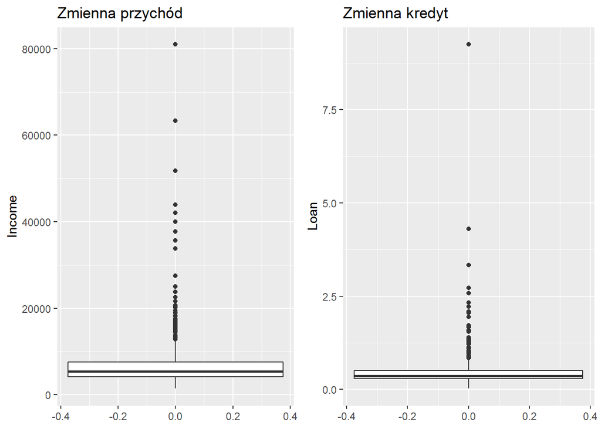

Pomimo wprowadzenia nowych zmiennych wartości odstające dalej występują, nie jest ich już jednak tak dużo jak wcześniej. Decyduje się usunąć obserwacje ze zmiennej przychód powyżej 30 000 oraz ze zmiennej kredyt powyżej 2.

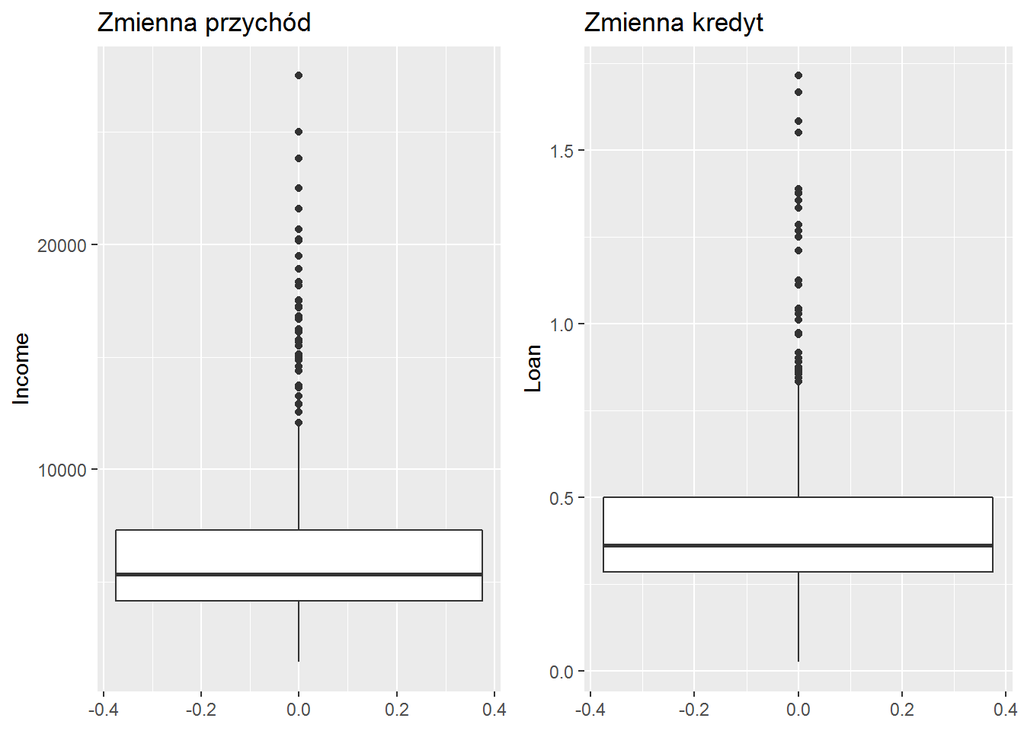

Niestety wartości odstające dalej występują. Nie są one jednak tak skrajne jak wcześniej i jest ich o wiele mniej. Pozostawiam więc dane w takiej postaci.

### Podział zbioru na uczący i testowy

Podzielę teraz swoje dane na zbiór uczący oraz testowy 80% moich danych będzie treningowych, a 20% testowych. Poniżej kod, który umożliwia mi podział.

```r
  set.seed(1)

  division   <- sample(nrow(data_imputed), round(0.8*nrow(data_imputed)), replace = F)

  train <- data_imputed[division,]
  test <- data_imputed[-division,]
```

W celu zbadania czy zbiory te są mniej więcej równe przedstawiam histogramy zmiennych czynnikowych oraz wykresy pudełkowe zmiennych numerycznych.

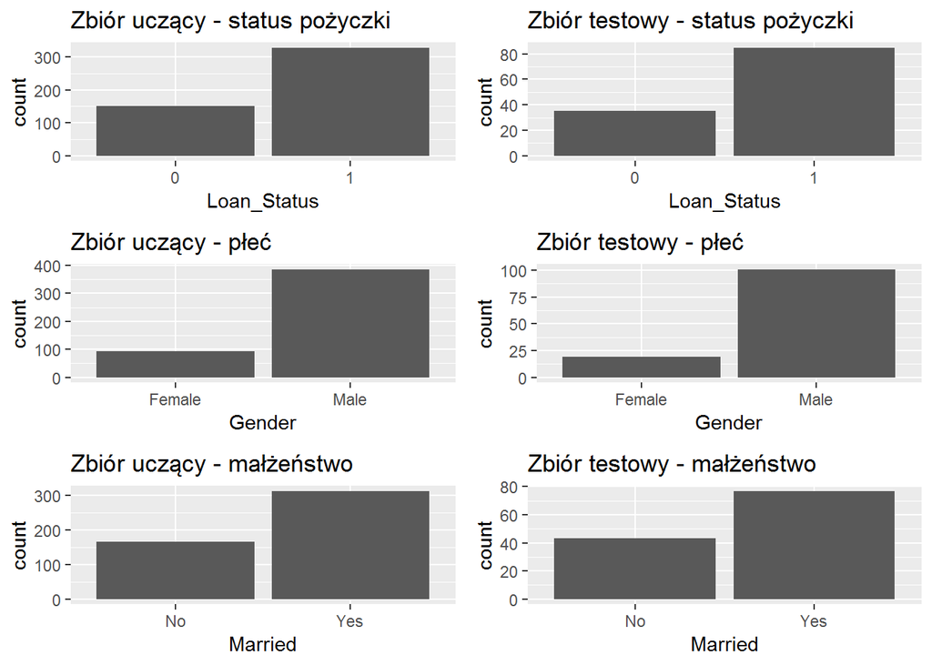

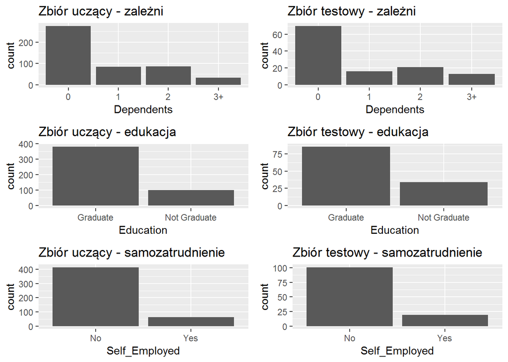

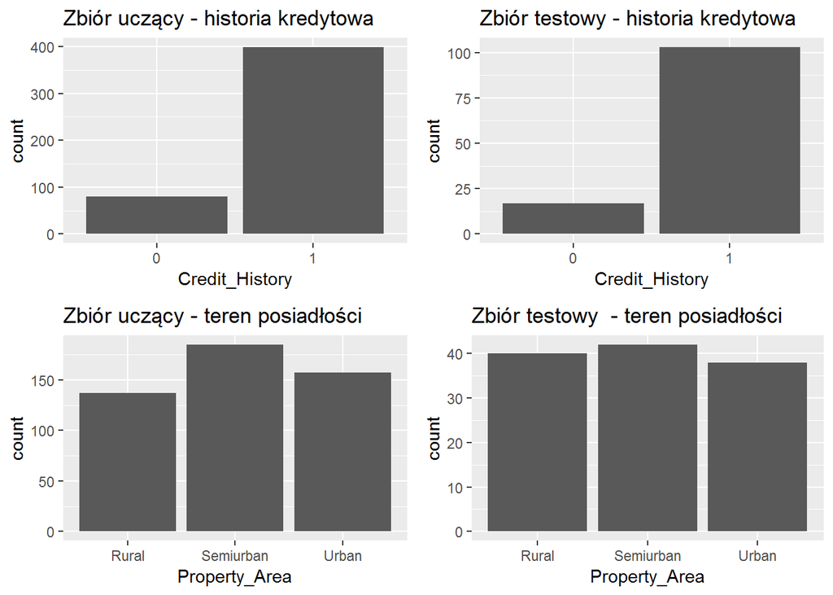

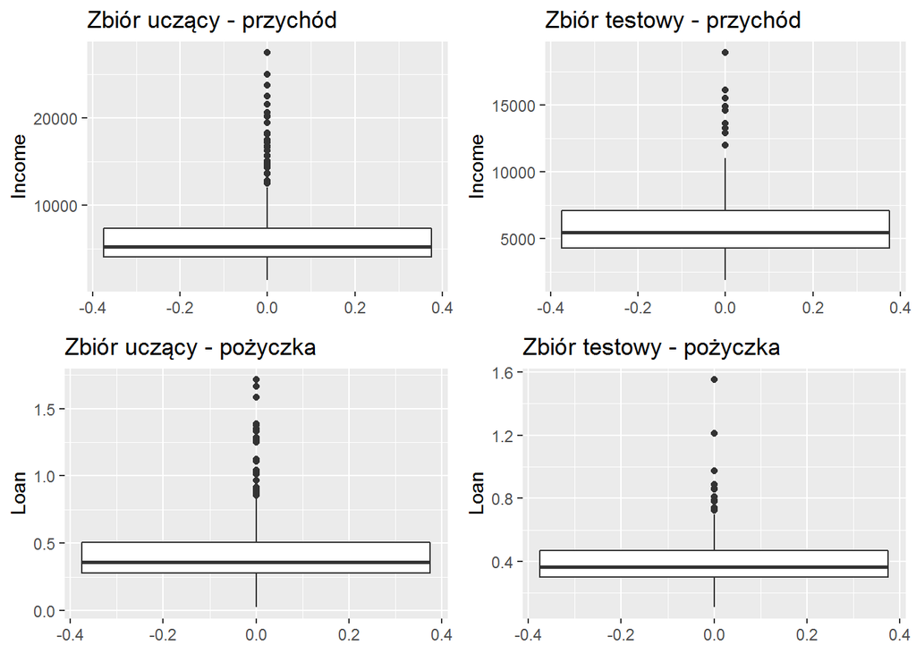

Wiadomo, że zbiory te nie są identyczne, lecz różnice w nich są niewielkie. Uznaję więc ten podział za wystarczająco dobry do dalszej części badania.

## Metody przewidywania

Jak już wspomniałam wcześniej w badaniu użyję 4 metod, a następnie postaram wybrać się najlepszą. Po każdej metodzie przedstawię macierz błędu. Przedstawię również krzywą ROC oraz wartość AUC.

### Regresja logistyczna

Regresja logistyczna to rodzaj regresji używany, gdy zmienna objaśniana przyjmuje tylko dwie wartości. Zmienne objaśniające mogą przyjmować charakter nominalny, porządkowy, przedziałowy lub ilorazowy. Model ten określa prawdopodobieństwo, że zmienna objaśniana (Y) należy do danej kategorii.

Krzywa logistyczna wyrażona jest poniższym wzorem:

$$p(X) = \frac{e^{\beta_0 + \beta_1X_1 + ... + \beta_pX_p}}{1 + e^{\beta_0 + \beta_1X_1 + ... + \beta_pX_p }}$$

gdzie $X = (X_1, ..., X_p)$ to p zmiennych objaśniających, a $\beta_0, ... \beta_p$ to współczynniki.

Po utworzeniu modelu będę przewidywać wartość Y za jego pomocą. Użyję wtedy również punktu odcięcia tj. od jakiej wartości prawdopodobieństwa będę przypisywać zmienną Y do 1. Ustalam go jako 0.69, gdyż w całym zbiorze występuje 69% przypadków, gdzie udzielono komuś kredytu.

Do stworzenia modelu regresji logistycznej użyję funkcji `glm` z pakietu `stats`.

Przedstawiam poniżej utworzony model.

```r
  log.model = glm(Loan_Status~., family = binomial, data=train)
  summary(log.model)
```

```
##
## Call:
## glm(formula = Loan_Status ~ ., family = binomial, data = train)
##
## Deviance Residuals:
##     Min       1Q   Median       3Q      Max
## -2.1543  -0.3643   0.5202   0.6672   2.5030
##
## Coefficients:
##                          Estimate Std. Error z value Pr(>|z|)
## (Intercept)            -2.813e+00  5.901e-01  -4.767 1.87e-06 ***
## GenderMale             -1.008e-01  3.518e-01  -0.287   0.7744
## MarriedYes              4.917e-01  3.081e-01   1.596   0.1106
## Dependents1             1.076e-01  3.664e-01   0.294   0.7690
## Dependents2             4.193e-01  3.935e-01   1.065   0.2867
## Dependents3+            7.179e-02  5.280e-01   0.136   0.8918
## EducationNot Graduate  -5.191e-01  3.034e-01  -1.711   0.0871 .
## Self_EmployedYes       -3.893e-01  3.632e-01  -1.072   0.2837
## Credit_History1         4.066e+00  4.546e-01   8.945  < 2e-16 ***
## Property_AreaSemiurban  7.185e-01  3.195e-01   2.249   0.0245 *
## Property_AreaUrban      8.193e-02  3.105e-01   0.264   0.7919
## Income                 -2.247e-05  4.093e-05  -0.549   0.5831
## Loan                   -1.753e-01  6.651e-01  -0.264   0.7921
## ---
## Signif. codes:  0 '***' 0.001 '**' 0.01 '*' 0.05 '.' 0.1 ' ' 1
##
## (Dispersion parameter for binomial family taken to be 1)
##
##     Null deviance: 595.49  on 478  degrees of freedom
## Residual deviance: 413.41  on 466  degrees of freedom
## AIC: 439.41
##
## Number of Fisher Scoring iterations: 5
```

Można zauważyć, że nie wszystkie zmienne okazały się być istotne. Na poziomie istotności 0.05 okazały się być ważne tylko dwie zmienne - historia kredytowa oraz miejsce posiadłości. Natomiast na poziomie 0.1 - edukacja. W celu stworzenia dokładniejszego modelu z mniejszą ilością zmiennych użyję funkcji `stepAIC` z pakietu `MASS`. Wykonuje ona wsteczno krokowy wybór modelu za pomocą AIC. Poniżej wynik funkcji oraz przedstawiony końcowy model.

```r
  stepAIC(log.model, trace = 0, direction = "backward")
```

```
##
## Call:  glm(formula = Loan_Status ~ Married + Education + Credit_History +
##     Property_Area, family = binomial, data = train)
##
## Coefficients:
##            (Intercept)              MarriedYes   EducationNot Graduate
##                -3.1076                  0.5054                 -0.4496
##        Credit_History1  Property_AreaSemiurban      Property_AreaUrban
##                 4.0358                  0.7613                  0.1303
##
## Degrees of Freedom: 478 Total (i.e. Null);  473 Residual
## Null Deviance:       595.5
## Residual Deviance: 416.9     AIC: 428.9
```

```r
  log.model2 <- glm(formula = Loan_Status ~ Married + Education + Credit_History +
        Property_Area, family = binomial, data = train)
  summary(log.model2)
```

```
##
## Call:
## glm(formula = Loan_Status ~ Married + Education + Credit_History +
##     Property_Area, family = binomial, data = train)
##
## Deviance Residuals:
##     Min       1Q   Median       3Q      Max
## -2.1450  -0.3781   0.5673   0.6540   2.5105
##
## Coefficients:
##                        Estimate Std. Error z value Pr(>|z|)
## (Intercept)             -3.1076     0.5132  -6.055 1.41e-09 ***
## MarriedYes               0.5054     0.2535   1.994   0.0462 *
## EducationNot Graduate   -0.4496     0.2934  -1.533   0.1254
## Credit_History1          4.0358     0.4509   8.951  < 2e-16 ***
## Property_AreaSemiurban   0.7613     0.3129   2.433   0.0150 *
## Property_AreaUrban       0.1303     0.3003   0.434   0.6643
## ---
## Signif. codes:  0 '***' 0.001 '**' 0.01 '*' 0.05 '.' 0.1 ' ' 1
##
## (Dispersion parameter for binomial family taken to be 1)
##
##     Null deviance: 595.49  on 478  degrees of freedom
## Residual deviance: 416.88  on 473  degrees of freedom
## AIC: 428.88
##
## Number of Fisher Scoring iterations: 5
```

Tym razem zmienna edukacja okazała się być nieistotna. Za to istotna jest zmienna małżeństwo.

Wykonam teraz predykcje na zbiorze treningowym. Przedstawię następnie macierz błędu, krzywą ROC oraz wartość AUC. W momencie, gdy krzywa ROC jest prostą, czyli wartość AUC wynosi 0.5, model sprawdza się tak samo jak rzut monetą. Im wyższa wartość AUC tym lepiej.

```
## Confusion Matrix and Statistics
##
##           Reference
## Prediction   0   1
##          0  82  17
##          1  68 312
##
##                Accuracy : 0.8225
##                  95% CI : (0.7853, 0.8557)
##     No Information Rate : 0.6868
##     P-Value [Acc > NIR] : 1.169e-11
##
##                   Kappa : 0.5454
##  Mcnemar's Test P-Value : 5.852e-08
##
##             Sensitivity : 0.9483
##             Specificity : 0.5467
##          Pos Pred Value : 0.8211
##          Neg Pred Value : 0.8283
##              Prevalence : 0.6868
##          Detection Rate : 0.6514
##    Detection Prevalence : 0.7933
##       Balanced Accuracy : 0.7475
##
##        'Positive' Class : 1
##
```

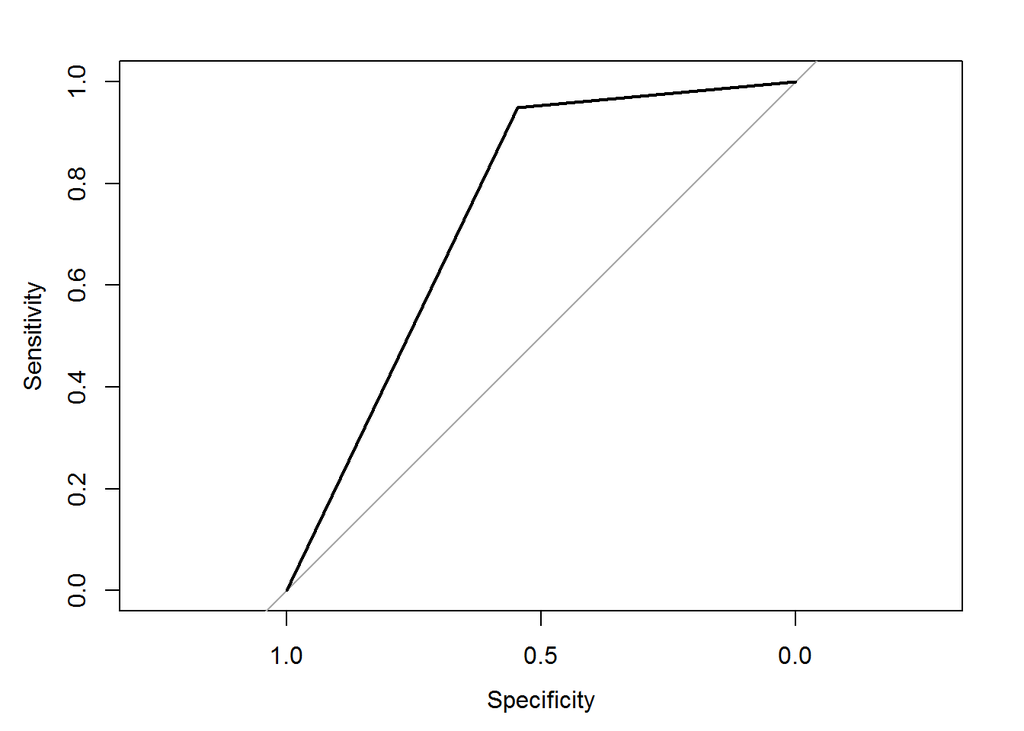

```
## Area under the curve: 0.7475
```

Przedstawię teraz jak sprawdza się model dla danych testowych.

```
## Confusion Matrix and Statistics
##
##           Reference
## Prediction  0  1
##          0 16  4
##          1 19 81
##
##                Accuracy : 0.8083
##                  95% CI : (0.7264, 0.8744)
##     No Information Rate : 0.7083
##     P-Value [Acc > NIR] : 0.008534
##
##                   Kappa : 0.4692
##  Mcnemar's Test P-Value : 0.003509
##
##             Sensitivity : 0.9529
##             Specificity : 0.4571
##          Pos Pred Value : 0.8100
##          Neg Pred Value : 0.8000
##              Prevalence : 0.7083
##          Detection Rate : 0.6750
##    Detection Prevalence : 0.8333
##       Balanced Accuracy : 0.7050
##
##        'Positive' Class : 1
##
```

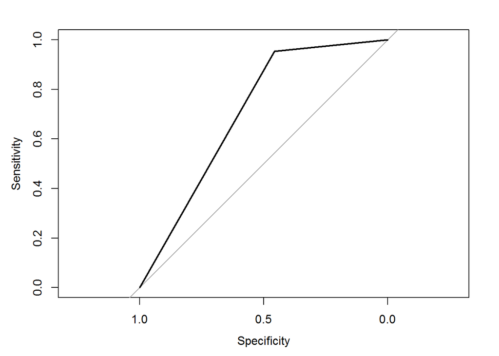

```
## Area under the curve: 0.705
```

Skuteczność modelu niewiele pogorszyła się względem zbioru treningowego. Wartość specyficzności w obu przypadkach jest niska - około 0.5, oznacza to, że obserwacje, gdzie odmówiono kredytu są słabo rozpoznawane. Wartość AUC również się pomniejszyła - wynosi 0.705.

### Klasyfikator naiwny Bayesa

Klasyfikator naiwny Bayesa to prosty klasyfikator opierający się na prawdopodobieństwach. Mimo prostoty metody, często działa ona lepiej od innych, bardzo skomplikowanych metod klasyfikujących. Teoria ta opiera się na założeniu o wzajemnej niezależności predykatorów.

Korzystając z twierdzenia Bayesa:

$$p(C|F_1,...F_n) = \frac{p(C)p(F_1,...f_n|C)}{p(F_1,...f_n)}$$

gdzie C to wartości klas (0,1), a F to zmienne objaśniające.

Ze względu na założenie o niezależności model ten można zapisać jako:

$$p(C|F_1,...F_n) = p(C)p(F_1|C)p(F_2|C)...p(f_n|C)$$

W metodzie tej również będę używać progu odcięcia i ustawię go ponownie na 0.69. Do wykonania tej metody posłużę się funkcją `naive_bayes` z pakietu `naivebayes`.

Z uwagi na to, że funkcja ta przyjmuje tylko zmienne czynnikowe zamieniam zmienne Loan oraz Income na takie. Tworzę w każdej z nich 4 grupy w zależności od kwartyli:

- pierwsza grupa mniejsza od pierwszego kwartyla,
- druga grupa mniejsza od mediany,
- trzecia grupa mniejsza od trzeciego kwartyla,
- czwarta grupa większa od trzeciego kwartyla.

Wykorzystam do tego funkcję `cut`. Poniżej kod, który mi to umożliwa.

```r
#zamienić wszystkie na factor
  train_fac <- train
  test_fac <- test

  #4 grupy w zaleznosci od kwartyli
  summary(data_imputed$Loan)
```

```
##    Min. 1st Qu.  Median    Mean 3rd Qu.    Max.
##  0.0250  0.2847  0.3611  0.4269  0.5000  1.7143
```

```r
  summary(data_imputed$Income)
```

```
##    Min. 1st Qu.  Median    Mean 3rd Qu.    Max.
##    1442    4163    5332    6422    7300   27500
```

```r
  loan_fac <- cut(data_imputed$Loan,breaks=c(0,0.2847, 0.3611,0.5,1.7143),labels = c("1","2","3","4"))
  income_fac <- cut(data_imputed$Income,breaks=c(0,4163, 5332,7300,27500),labels = c("1","2","3","4"))

  train_fac$Loan <- loan_fac[division]
  train_fac$Income <- income_fac[division]
  train_fac = data.frame(train_fac[,-8], Loan_Status = train_fac[,8])

  test_fac$Loan <- loan_fac[-division]
  test_fac$Income <- income_fac[-division]
  test_fac = data.frame(test_fac[,-8], Loan_Status = test_fac[,8])
```

Wykonam teraz model, a następnie przedstawię jego macierz błędu oraz krzywą ROC na zbiorze treningowym.

```r
nb.model <- naive_bayes(Loan_Status~.,data=train_fac)

  #train
  nb.pred.train <- predict(nb.model, train_fac,type="prob")[,2]
  nb.pred.train <- ifelse(nb.pred.train>.69, 1, 0)

  tmp<-confusionMatrix(as.factor(nb.pred.train), train_fac$Loan_Status, positive = '1')
  tmp
```

```
## Confusion Matrix and Statistics
##
##           Reference
## Prediction   0   1
##          0  89  24
##          1  61 305
##
##                Accuracy : 0.8225
##                  95% CI : (0.7853, 0.8557)
##     No Information Rate : 0.6868
##     P-Value [Acc > NIR] : 1.169e-11
##
##                   Kappa : 0.5578
##  Mcnemar's Test P-Value : 9.432e-05
##
##             Sensitivity : 0.9271
##             Specificity : 0.5933
##          Pos Pred Value : 0.8333
##          Neg Pred Value : 0.7876
##              Prevalence : 0.6868
##          Detection Rate : 0.6367
##    Detection Prevalence : 0.7641
##       Balanced Accuracy : 0.7602
##
##        'Positive' Class : 1
##
```

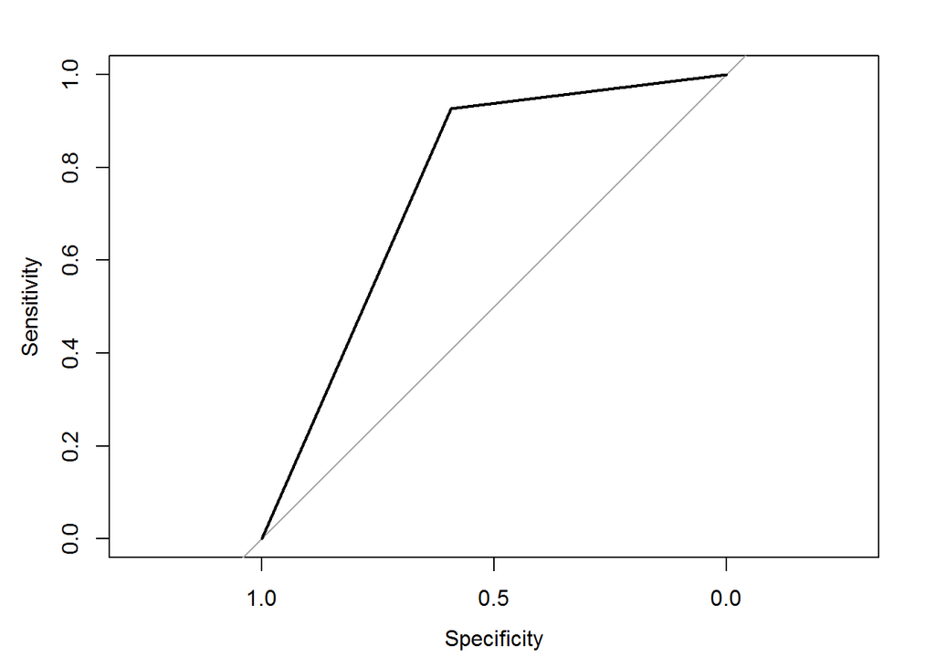

```r
  acc_nb_tr <- tmp$overall[1]

  ROC <- roc(train_fac$Loan_Status, nb.pred.train)
  plot(ROC)
```

```r
  auc_nb_tr <- auc(ROC)
  auc_nb_tr
```

```
## Area under the curve: 0.7602
```

Wyniki na zbiorze treningowym są bardzo podobne do wyników regresji logistycznej również na tym zbiorze. Skuteczność wynosi 0.82, specyficzność jest o wiele niższa od wrażliwości, a wartość AUC wynosi 0.76.

Teraz analogicznie przedstawię wyniki dla zbioru testowego.

```
## Confusion Matrix and Statistics
##
##           Reference
## Prediction  0  1
##          0 20  9
##          1 15 76
##
##                Accuracy : 0.8
##                  95% CI : (0.7172, 0.8675)
##     No Information Rate : 0.7083
##     P-Value [Acc > NIR] : 0.01509
##
##                   Kappa : 0.4903
##  Mcnemar's Test P-Value : 0.30743
##
##             Sensitivity : 0.8941
##             Specificity : 0.5714
##          Pos Pred Value : 0.8352
##          Neg Pred Value : 0.6897
##              Prevalence : 0.7083
##          Detection Rate : 0.6333
##    Detection Prevalence : 0.7583
##       Balanced Accuracy : 0.7328
##
##        'Positive' Class : 1
##
```

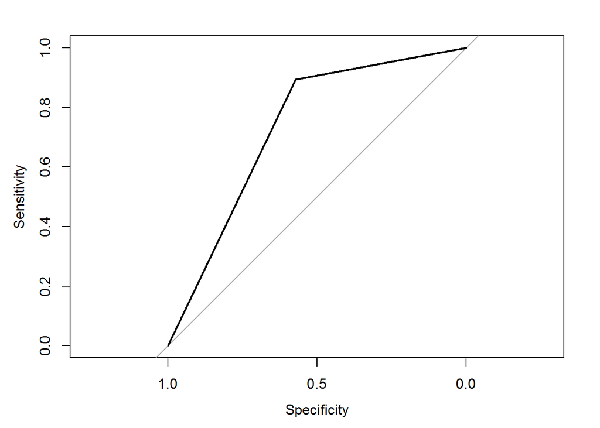

```
## Area under the curve: 0.7328
```

Można zauważyć jednak, że w przypadku zbioru testowego sprawdza się lepiej niż regresja logistyczna. Niestety ponownie specyficzność jest niska.

### Boosting

Boosting to podejście w celu zwiększenia dokładności predykcji zwykłego drzewa decyzyjnego. Drzewa powstają sekwencyjnie - każde drzewo jest tworzone używając informacji z poprzednich drzew. Każde drzewo powstaje na zmodyfikowanej wersji zbioru początkowego.

Metoda boosting uczy się relatywnie wolno. Biorąc obecny model, dopasowuje się drzewo do reszt z niego. W momencie tworzenia nowych drzew bierze się pod uwagę właśnie reszty, a nie zmienną objaśnianą Y. Za pomocą nowo utworzonego drzewa aktualizuje się reszty. Każde z tych drzew może być małe, definiuje to parametr d, który ustala się samemu. W ten sposób powoli poprawia się dokładność f ^ w regułach, gdzie były największe problemy. Parametr kurczenia się lambda jeszcze bardziej zwalnia spowalnia ten proces, aby więcej różnych drzew mogło wpłynąć na reszty.

W celu wykonania tego algorytmu posłużę się funkcją `gbm` z pakietu o tej samej nazwę. Ponownie punkt odcięcia przy predykcji ustawię na 0.69. Funkcja ta jako zmienną objaśnianą nie przyjmuje zmiennej czynnikowej, lecz numeryczną. Zamieniam więc ją na taką. W celu zapewnienia powtarzalności drzew używam funkcji `set.seed`.

Funkcja `gbm` przyjmuje wiele parametrów. Najpierw ustalam ilość drzew jako 10000, a pozostałych nie zmieniam. Poniżej przedstawiam w jaki sposób tworzę drzewo, a następnie macierz błędu oraz krzywą ROC dla otrzymanego modelu na danych treningowych.

```r
  train_num <- train
  train_num$Loan_Status <- as.numeric(train_num$Loan_Status)-1
  test_num <- test
  test_num$Loan_Status <- as.numeric(test_num$Loan_Status)-1

  set.seed(1)
  boostTree <- gbm(Loan_Status~.,data=train_num, n.trees = 10000, distribution = "bernoulli")

  #train
  boost.pred.train <- predict(boostTree, newdata = train_num, n.trees = 10000, type="response")
  boost.pred.train <- ifelse(boost.pred.train>0.69, 1, 0)

  tmp <- confusionMatrix(as.factor(boost.pred.train), as.factor(train_num$Loan_Status), positive = '1')
  tmp
```

```
## Confusion Matrix and Statistics
##
##           Reference
## Prediction   0   1
##          0 148  16
##          1   2 313
##
##                Accuracy : 0.9624
##                  95% CI : (0.9413, 0.9776)
##     No Information Rate : 0.6868
##     P-Value [Acc > NIR] : < 2.2e-16
##
##                   Kappa : 0.9148
##  Mcnemar's Test P-Value : 0.002183
##
##             Sensitivity : 0.9514
##             Specificity : 0.9867
##          Pos Pred Value : 0.9937
##          Neg Pred Value : 0.9024
##              Prevalence : 0.6868
##          Detection Rate : 0.6534
##    Detection Prevalence : 0.6576
##       Balanced Accuracy : 0.9690
##
##        'Positive' Class : 1
##
```

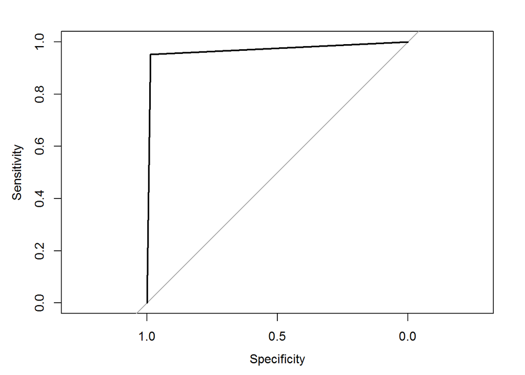

```r
  acc_boost_tr <- tmp$overall[1]

  ROC <- roc(train_num$Loan_Status, boost.pred.train)
  plot(ROC)
```

```r
  auc_boost_tr <- auc(ROC)
  auc_boost_tr
```

```
## Area under the curve: 0.969
```

Jak widać w tej metodzie wzrosła zarówno wartość ACC jak i AUC. Również warto zauważyć, iż wzrosła wartość specyficzności. Model ten bardzo dobrze sprawdza się dla danych treningowych. Wartości są bliskie 1. Tak dobre wyniki mogą świadczyć o przeuczeniu modelu.

Analogicznie przedstawię teraz wyniki otrzymane dla zbioru testowego.

```
## Confusion Matrix and Statistics
##
##           Reference
## Prediction  0  1
##          0 22 22
##          1 13 63
##
##                Accuracy : 0.7083
##                  95% CI : (0.6184, 0.7877)
##     No Information Rate : 0.7083
##     P-Value [Acc > NIR] : 0.5455
##
##                   Kappa : 0.3438
##  Mcnemar's Test P-Value : 0.1763
##
##             Sensitivity : 0.7412
##             Specificity : 0.6286
##          Pos Pred Value : 0.8289
##          Neg Pred Value : 0.5000
##              Prevalence : 0.7083
##          Detection Rate : 0.5250
##    Detection Prevalence : 0.6333
##       Balanced Accuracy : 0.6849
##
##        'Positive' Class : 1
##
```

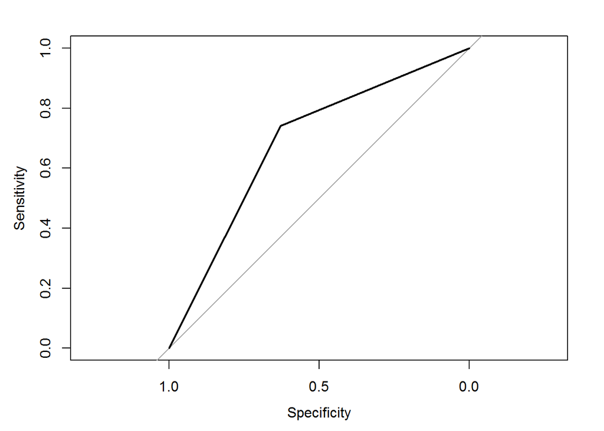

```
## Area under the curve: 0.6849
```

Niestety dla danych testowych model ten okazuje się być o wiele słabszy - ACC maleje do 0.708, a AUC do 0.68. Jest to niepokojące.

Przedstawię teraz jak kształtuje się wpływ zmiennych objaśniających na model przy pomocy funkcji `summary`.

```r
  par(mar = c(5, 8, 1, 1))
  summary(boostTree, las=2)
```

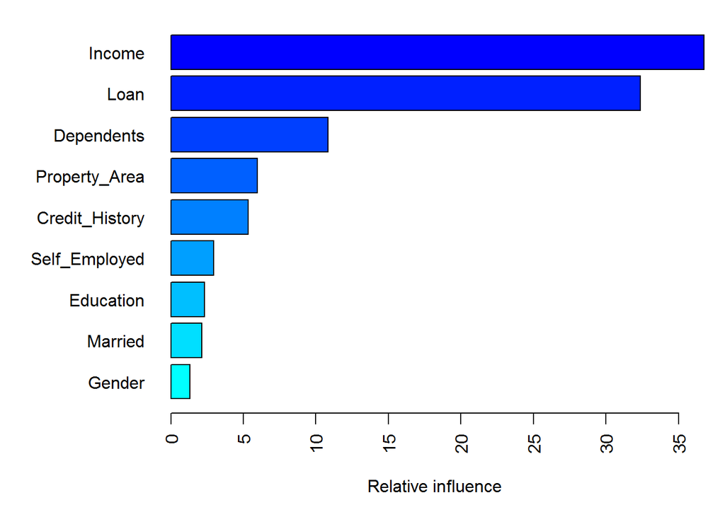

```
##                           var   rel.inf
## Income                 Income 36.759821
## Loan                     Loan 32.386433
## Dependents         Dependents 10.838789
## Property_Area   Property_Area  5.982703
## Credit_History Credit_History  5.321601
## Self_Employed   Self_Employed  2.955229
## Education           Education  2.325765
## Married               Married  2.126506
## Gender                 Gender  1.303151
```

Okazało się, że przy użyciu tej metody dla modelu najważniejsze są zmienne: przychód, kredyt oraz liczba osób zależnych. Zmienne płeć oraz małżeństwo są najmniej ważne. Bardzo szokujące jest to, że zmienna historia kredytowa nie wpływa bardzo na model.

Spróbuje teraz polepszyć wyniki modelu. Najpierw użyję funkcji `gbm.perf`, która pozwoli otrzymać optymalną ilość drzew, które powinny zostać wykonane do stworzenia modelu.

```r
  #najlepsza ilość drzew
  gbm.perf(object = boostTree,method="OOB")
```

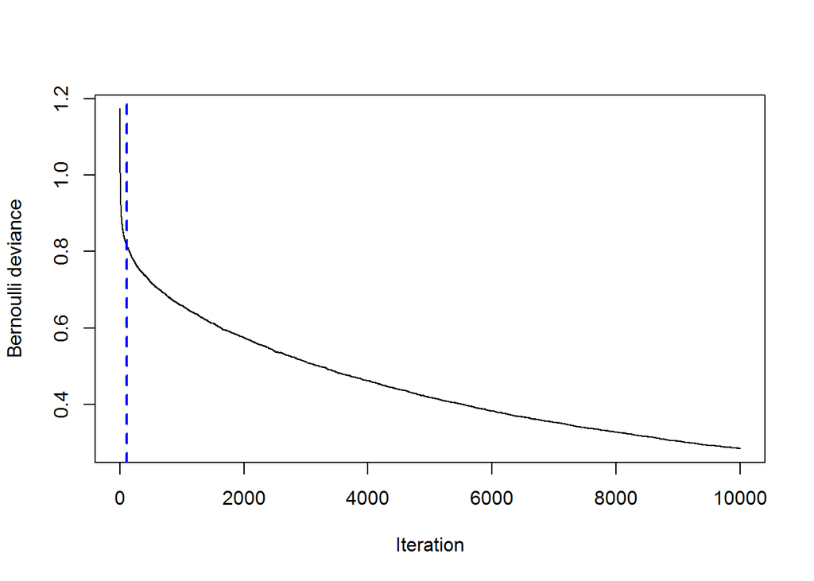

```
## [1] 108
## attr(,"smoother")
## Call:
## loess(formula = object$oobag.improve ~ x, enp.target = min(max(4,
##     length(x)/10), 50))
##
## Number of Observations: 10000
## Equivalent Number of Parameters: 39.99
## Residual Standard Error: 0.0006669628
```

Jak widać optymalna ilość drzew została określona jako 108.

Za pomocą poniższego kodu będę zmieniać wartości parametrów funkcji `gbm`, a następnie zbadam wartości ACC i wybiorę ten zbiór parametrów dla którego przyjmuje największą wartość.

```r
  #najlepsze params
  hyper_grid <- expand.grid(
    shrinkage = c(.001,.01, .1, .3),
    interaction.depth = c(1, 3, 5,7),
    n.minobsinnode=c(5,10,15),
    n.trees = c(108)
  )

  acc <- c()

  for (i in 1:nrow(hyper_grid)) {

    set.seed(1)

    model <- gbm(formula = Loan_Status ~ .,
                 data = train_num,
                 distribution = "bernoulli",
                 n.trees=hyper_grid$n.trees[i],
                 interaction.depth = hyper_grid$interaction.depth[i],
                 shrinkage = hyper_grid$shrinkage[i]
    )


    pred <- predict(object = model,newdata = test_num, n.trees = hyper_grid$n.trees[i], type="response")
    pred <- ifelse(pred>0.69, 1, 0)


    tmp <- confusionMatrix(as.factor(pred), as.factor(test_num$Loan_Status), positive = '1')
    acc[i] <- tmp$overall[1]

  }

  opt_i_acc <- which.max(acc)
  print(hyper_grid[opt_i_acc,])
```

```
##   shrinkage interaction.depth n.minobsinnode n.trees
## 1     0.001                 1              5     108
```

```
## Confusion Matrix and Statistics
##
##           Reference
## Prediction   0   1
##          0  74   6
##          1  76 323
##
##                Accuracy : 0.8288
##                  95% CI : (0.792, 0.8615)
##     No Information Rate : 0.6868
##     P-Value [Acc > NIR] : 1.135e-12
##
##                   Kappa : 0.5442
##  Mcnemar's Test P-Value : 2.541e-14
##
##             Sensitivity : 0.9818
##             Specificity : 0.4933
##          Pos Pred Value : 0.8095
##          Neg Pred Value : 0.9250
##              Prevalence : 0.6868
##          Detection Rate : 0.6743
##    Detection Prevalence : 0.8330
##       Balanced Accuracy : 0.7375
##
##        'Positive' Class : 1
##
```

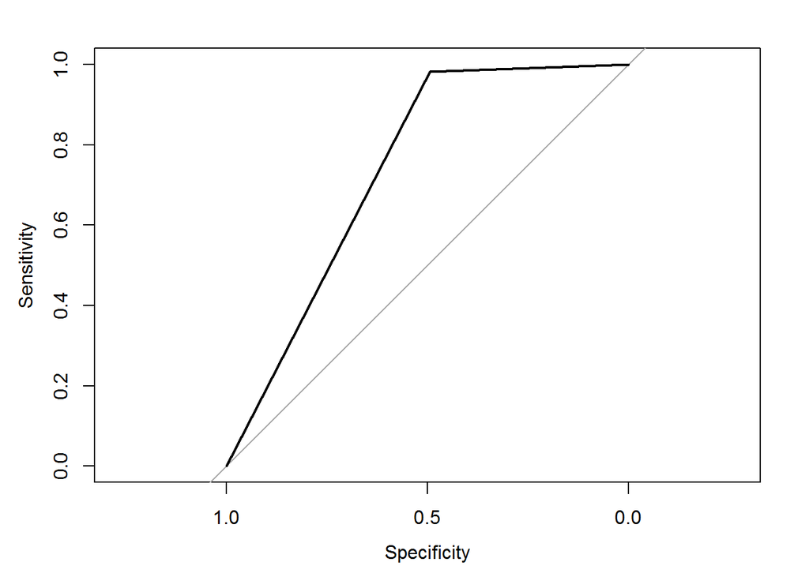

```
## Area under the curve: 0.7375
```

Jak widać w porównaniu z pierwszym modelem wyniki są o wiele gorsze. Specyficzność wynosi mniej niż 0.5. Przedstawię jak kształtują się wyniki dla zbioru testowego.

```
## Confusion Matrix and Statistics
##
##           Reference
## Prediction  0  1
##          0 16  1
##          1 19 84
##
##                Accuracy : 0.8333
##                  95% CI : (0.7544, 0.8951)
##     No Information Rate : 0.7083
##     P-Value [Acc > NIR] : 0.0011413
##
##                   Kappa : 0.5248
##  Mcnemar's Test P-Value : 0.0001439
##
##             Sensitivity : 0.9882
##             Specificity : 0.4571
##          Pos Pred Value : 0.8155
##          Neg Pred Value : 0.9412
##              Prevalence : 0.7083
##          Detection Rate : 0.7000
##    Detection Prevalence : 0.8583
##       Balanced Accuracy : 0.7227
##
##        'Positive' Class : 1
##
```

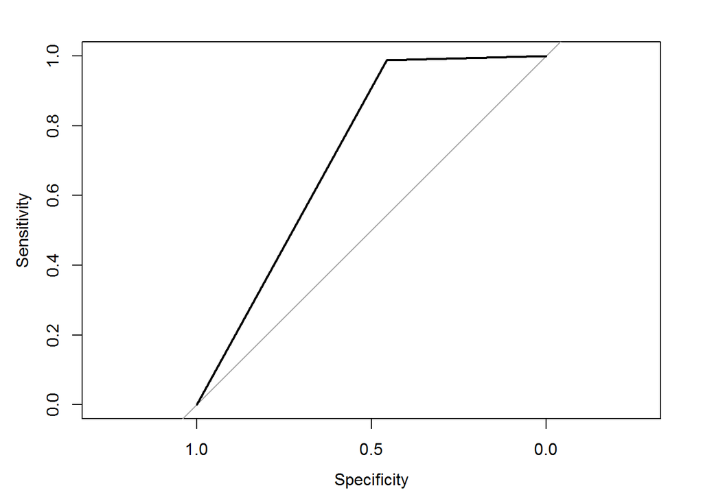

```
## Area under the curve: 0.7227
```

Jednak wyniki dla zbioru testowego są lepsze niż w przypadku pierwszego modelu. Specyficzność ciągle jednak jest niska.

Przedstawię teraz jakie zmienne mają wpływ na model.

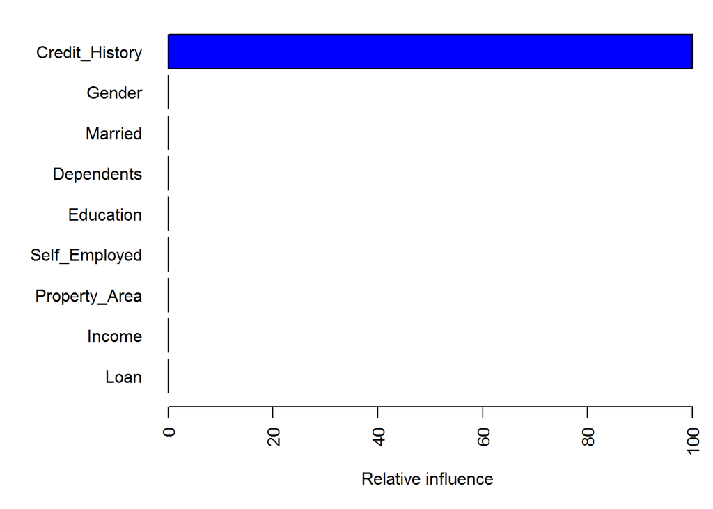

```
##                           var rel.inf
## Credit_History Credit_History     100
## Gender                 Gender       0
## Married               Married       0
## Dependents         Dependents       0
## Education           Education       0
## Self_Employed   Self_Employed       0
## Property_Area   Property_Area       0
## Income                 Income       0
## Loan                     Loan       0
```

Model opiera się tylko na jednej zmiennej - historia kredytowa. Jak widać można uzyskać całkiem dobre wyniki opierając się tylko na niej. Jest to zaskakujące - w pierwszym modelu zmienna ta nie okazała się być ważna. Warto się też zastanowić czy wyniki otrzymane za pomocą tej metody są wystarczająco dobre - znacznie skróciłoby to procedury decyzji o otrzymaniu kredytu.

### Lasy losowe

Zwykłe drzewo regresyjne ma bardzo dużą wariancję, czyli jeżeli podzieli się dane treningowe losowo na pół i stworzy się dla każdego podzbioru drzewo regresyjne to mogą się one okazać zupełnie różne. Lasy losowe zmniejszają wariancję pojedynczych drzew, lecz dodatkowo dekorelują drzewa. W przypadku, gdy występuje jeden mocny predykator, prawdopodobnie większość drzew będzie wykorzystywać tą zmienną na samym początku. Spowoduje to, że drzewa będą do siebie bardzo podobne, więc prognozy z nich będą silnie skorelowane. W wyniku tego wariancja drzew nie zostanie tak bardzo zredukowana jak w przypadku nieskorelowanych drzew. Lasy losowe rozwiązują ten problem poprzez niewykorzystywanie wszystkich zmiennych objaśniających.

Algorytm lasów losowych :

1. Ze zbioru treningowego losuje się ze zwracaniem B różnych podzbiorów. Zazwyczaj liczebność podzbiorów jest taka sama jak zbioru treningowego.
2. Następnie losuje się m zmiennych objaśniających z p możliwych (m < p). Zazwyczaj m = $\sqrt{p}$.
3. Dla każdego podzbioru tworzy się drzewo regresyjne i dokonuje się predykcji na jego podstawie.
4. Końcowa predykcja to uśrednienie predykatorów powstałych z wielu podzbiorów.

Jak widać algorytm ten może poprawić wyniki poprzedniego modelu, gdyż nie w każdym drzewie będzie brana pod uwagę zmienna historia kredytowa.

Do wykonania tego modelu użyję funkcji `randomForest` z pakietu o tej samej nazwie. Tak samo jak w poprzednich metodach użyję punktu odcięcia 0.69.

Poniżej przedstawiam model z domyślnymi wartościami parametrów funkcji oraz macierz błędu z krzywą ROC dla zbioru treningowego.

```r
set.seed(222)

  rforest <- randomForest(Loan_Status ~ ., data=train)

  #train

  rf.pred.train <- predict(object = rforest,newdata = train, type = "prob")[,2]
  rf.pred.train <- ifelse(rf.pred.train>.69, 1, 0)

  tmp<-confusionMatrix(as.factor(rf.pred.train), as.factor(train$Loan_Status), positive = '1')
  tmp
```

```
## Confusion Matrix and Statistics
##
##           Reference
## Prediction   0   1
##          0 150   7
##          1   0 322
##
##                Accuracy : 0.9854
##                  95% CI : (0.9701, 0.9941)
##     No Information Rate : 0.6868
##     P-Value [Acc > NIR] : < 2e-16
##
##                   Kappa : 0.9665
##  Mcnemar's Test P-Value : 0.02334
##
##             Sensitivity : 0.9787
##             Specificity : 1.0000
##          Pos Pred Value : 1.0000
##          Neg Pred Value : 0.9554
##              Prevalence : 0.6868
##          Detection Rate : 0.6722
##    Detection Prevalence : 0.6722
##       Balanced Accuracy : 0.9894
##
##        'Positive' Class : 1
##
```

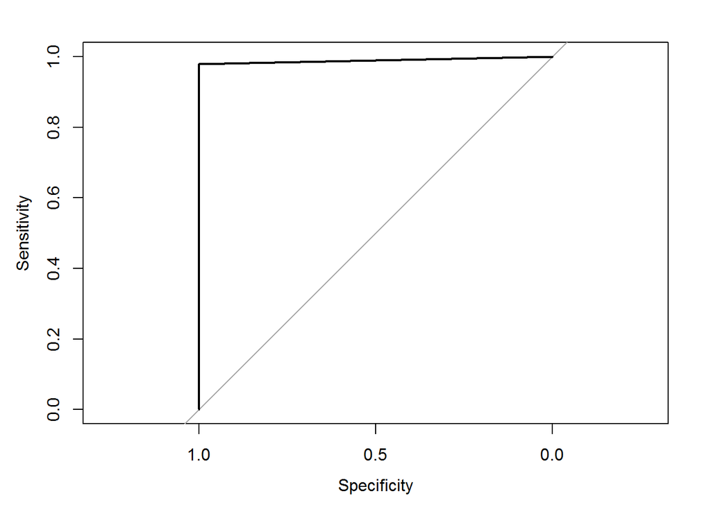

```r
  acc_rf_tr <- tmp$overall[1]

  ROC <- roc(train$Loan_Status, rf.pred.train)
  plot(ROC)
```

```r
  auc_rf_tr <- auc(ROC)
  auc_rf_tr
```

```
## Area under the curve: 0.9894
```

Jak widać zarówno ACC jak i AUC jest bliskie 1. Ponownie może to świadczyć o przeuczeniu modelu. Przedstawię teraz wyniki dla danych testowych.

```
## Confusion Matrix and Statistics
##
##           Reference
## Prediction  0  1
##          0 19 13
##          1 16 72
##
##                Accuracy : 0.7583
##                  95% CI : (0.6717, 0.8318)
##     No Information Rate : 0.7083
##     P-Value [Acc > NIR] : 0.1339
##
##                   Kappa : 0.4
##  Mcnemar's Test P-Value : 0.7103
##
##             Sensitivity : 0.8471
##             Specificity : 0.5429
##          Pos Pred Value : 0.8182
##          Neg Pred Value : 0.5937
##              Prevalence : 0.7083
##          Detection Rate : 0.6000
##    Detection Prevalence : 0.7333
##       Balanced Accuracy : 0.6950
##
##        'Positive' Class : 1
##
```

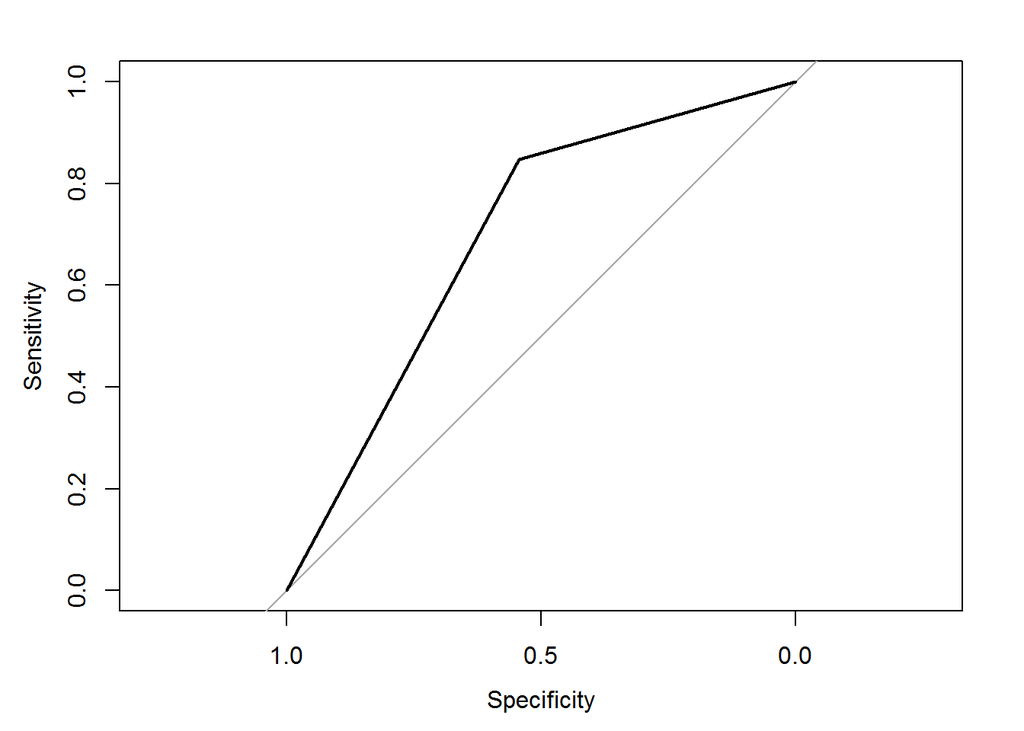

```
## Area under the curve: 0.695
```

Ponownie, jak w przypadku metody boosting, obie miary znacząco się pogorszyły. Jest to bardzo niepożądane. W dalszych krokach postaram się dopasować parametry modelu tak, by poprawić skuteczność modelu.

Za pomocą funkcji `varImpPlot` przedstawię, które zmienne istotnie wpływają na powstały model.

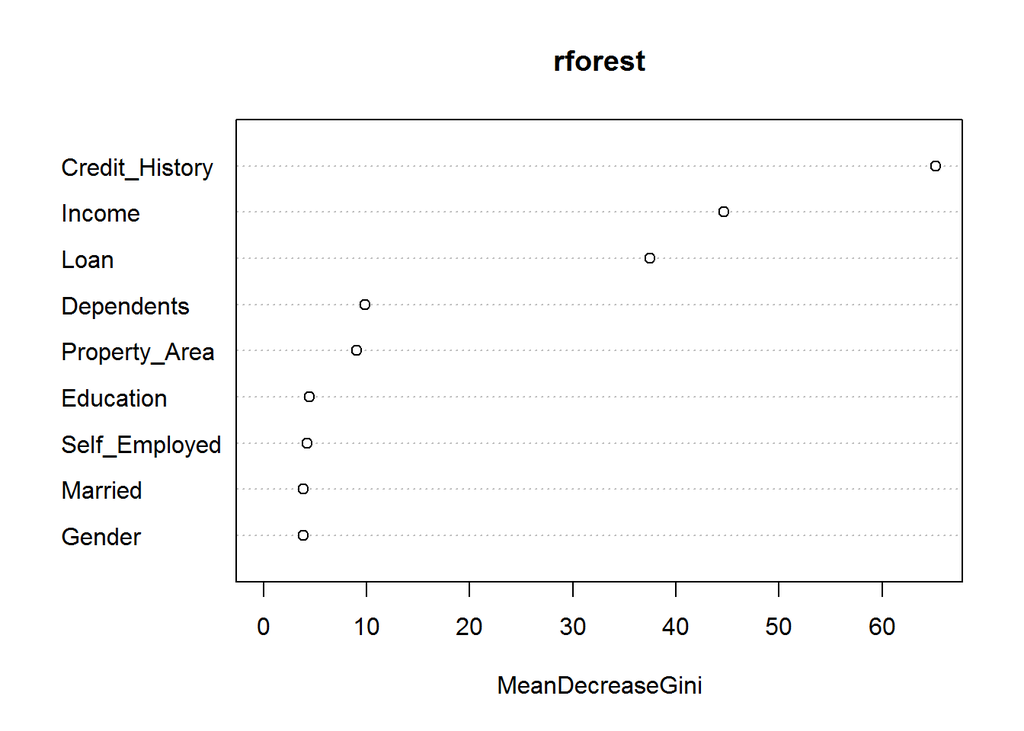

```r
  varImpPlot(rforest)
```

Najważniejsza jest zmienna historia kredytu, a następnie przychód i pożyczka. Ponownie najmniej istotne okazały się być zmienne płeć oraz małżeństwo.

Przedstawię teraz kod za pomocą, którego sprawdzę różne kombinacje parametrów funkcji, a za końcowe wybiorę te za pomocą, których otrzymana została największa wartość ACC.

```r
 #najlepsze param
  hyper_grid <- expand.grid(
    mtry=seq(1, 9, 1), #9 zminnych objaśniających
    nodesize=seq(2, 8, 1),
    ntree=c(100, 200, 500, 800, 1000, 5000, 8000)
  )

  acc <- c()

  for (i in 1:nrow(hyper_grid)) {

    set.seed(222)

    model <- randomForest(formula = Loan_Status ~ .,
                          data = train,
                          mtry = hyper_grid$mtry[i],
                          nodesize = hyper_grid$nodesize[i],
                          ntree = hyper_grid$ntree[i])

    pred <- predict(object = model,newdata = test, type="response")

    tmp <- confusionMatrix(as.factor(pred), as.factor(test$Loan_Status))
    acc[i] <- tmp$overall[1]

  }

  opt_i_acc <- which.max(acc)
  print(hyper_grid[opt_i_acc,])
```

```
##     mtry nodesize ntree
## 113    5        7   200
```

```r
  set.seed(222)

  rforest <- randomForest(formula = Loan_Status ~ .,
                           data = train,
                           mtry = 5,
                           nodesize = 7,
                           ntree=200)

  #train

  rf.pred.train <- predict(object = rforest,newdata = train, type = "prob")[,2]
  rf.pred.train <- ifelse(rf.pred.train>.69, 1, 0)

  tmp<-confusionMatrix(as.factor(rf.pred.train), as.factor(train$Loan_Status), positive = '1')
  tmp
```

```
## Confusion Matrix and Statistics
##
##           Reference
## Prediction   0   1
##          0 150  22
##          1   0 307
##
##                Accuracy : 0.9541
##                  95% CI : (0.9313, 0.971)
##     No Information Rate : 0.6868
##     P-Value [Acc > NIR] : < 2.2e-16
##
##                   Kappa : 0.8973
##  Mcnemar's Test P-Value : 7.562e-06
##
##             Sensitivity : 0.9331
##             Specificity : 1.0000
##          Pos Pred Value : 1.0000
##          Neg Pred Value : 0.8721
##              Prevalence : 0.6868
##          Detection Rate : 0.6409
##    Detection Prevalence : 0.6409
##       Balanced Accuracy : 0.9666
##
##        'Positive' Class : 1
##
```

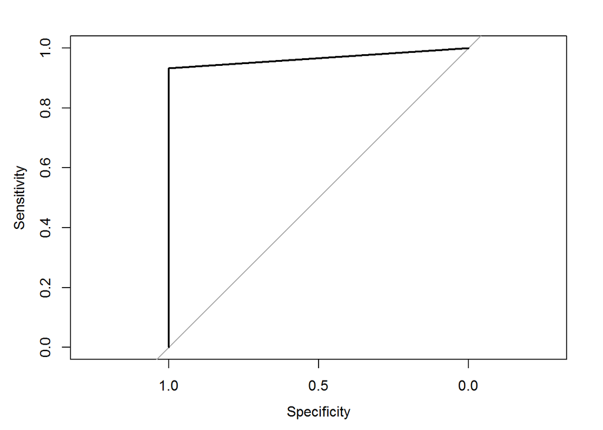

```r
  acc_rf_tr <- tmp$overall[1]

  ROC <- roc(train$Loan_Status, rf.pred.train)
  plot(ROC)
```

```r
  auc_rf_tr <- auc(ROC)
  auc_rf_tr
```

```
## Area under the curve: 0.9666
```

```
## Confusion Matrix and Statistics
##
##           Reference
## Prediction  0  1
##          0 23 19
##          1 12 66
##
##                Accuracy : 0.7417
##                  95% CI : (0.6538, 0.8172)
##     No Information Rate : 0.7083
##     P-Value [Acc > NIR] : 0.2433
##
##                   Kappa : 0.4095
##  Mcnemar's Test P-Value : 0.2812
##
##             Sensitivity : 0.7765
##             Specificity : 0.6571
##          Pos Pred Value : 0.8462
##          Neg Pred Value : 0.5476
##              Prevalence : 0.7083
##          Detection Rate : 0.5500
##    Detection Prevalence : 0.6500
##       Balanced Accuracy : 0.7168
##
##        'Positive' Class : 1
##
```

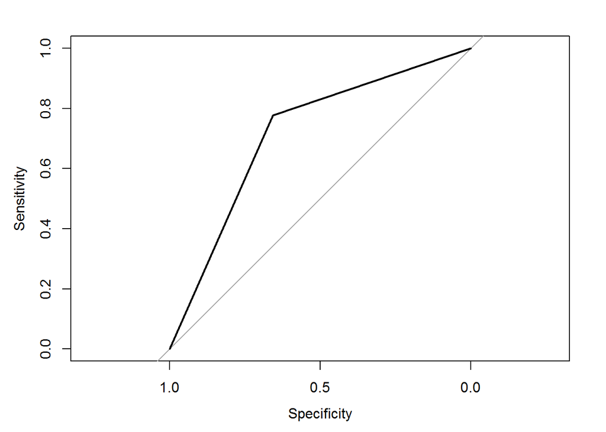

```
## Area under the curve: 0.7168
```

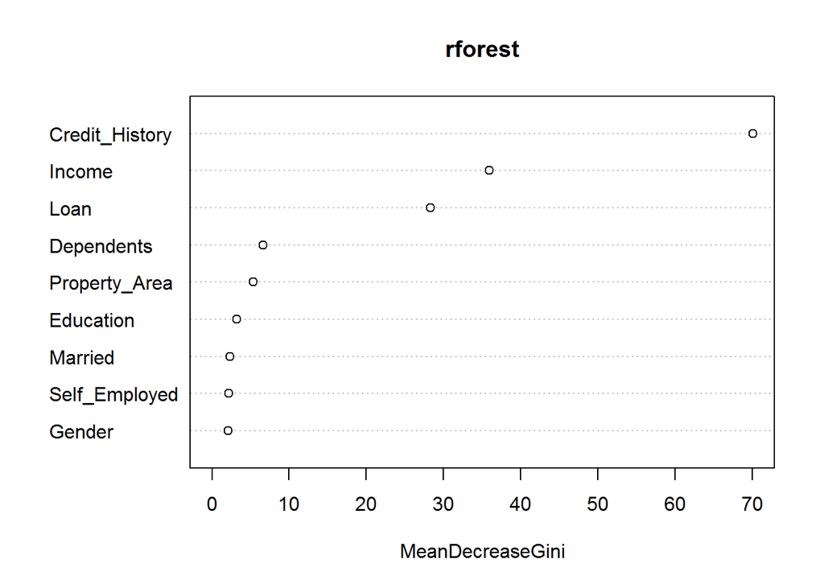

Istotność zmiennych jest bardzo podobna jak w przypadku pierwszego modelu. Ponownie najważniejsza okazała się być zmienna historia kredytowa, a następnie przychód oraz kredyt.

## Wnioski

Przedstawię teraz wyniki ACC i AUC dla każdej metody dla zbiorów testowych i treningowych.

```
##               acc.tr    auc.tr  acc.test  auc.test
## regresja    0.822547 0.7474975 0.8083333 0.7050420
## Bayes       0.822547 0.7601925 0.8000000 0.7327731
## boosting    0.828810 0.7375481 0.8333333 0.7226891
## lasy losowe 0.954071 0.9665653 0.7416667 0.7168067
```

Jako najlepsze metody mogę wybrać klasyfikator naiwny Bayesa oraz boosting. Boosting ma wyższe wartości ACC, a Bayes AUC.

Zaskakujące jest to, że tak prosta metoda jak klasyfikator naiwny Bayesa okazała się być jedną z lepszych. Po metodzie boosting spodziewałabym się lepszych wyników. Ponownie zaskakujący jest fakt, że jako jeden z lepszych modeli okazał się być ten, który bierze pod uwagę jedną zmienną - historię kredytową. Warto więc się zastanowić czy takie wyniki modelu są wystarczające.

Niestety mimo prób dopasowania parametrów modelu w lasach losowych model ten dalej jest przeuczony, a wyniki na zbiorze testowym nie są zbytnio dobre.

W celu poprawienia wyników można by próbować stworzyć model, gdzie w przypadku pozytywnej historii kredytowej zatwierdzano wniosek o kredyt, a w przypadku negatywnej stworzyć model, który nie bierze pod uwagę tej zmiennej. Myślę, że mogłoby to poprawić skuteczność modelu.